# IntroR

Liliana Lopez-Kleine

28 de noviembre de 2017

This is a brief introduction on basic data manipulation and on how to perform basic statistical analysis using R.

R is an open source program and has many contributors

```r
licence()
```

```
##
## This software is distributed under the terms of the GNU General
## Public License, either Version 2, June 1991 or Version 3, June 2007.
## The terms of version 2 of the license are in a file called COPYING
## which you should have received with
## this software and which can be displayed by RShowDoc("COPYING").
## Version 3 of the license can be displayed by RShowDoc("GPL-3").
##
## Copies of both versions 2 and 3 of the license can be found
## at https://www.R-project.org/Licenses/.
##
## A small number of files (the API header files listed in
## R_DOC_DIR/COPYRIGHTS) are distributed under the
## LESSER GNU GENERAL PUBLIC LICENSE, version 2.1 or later.
## This can be displayed by RShowDoc("LGPL-2.1"),
## or obtained at the URI given.
## Version 3 of the license can be displayed by RShowDoc("LGPL-3").
##
## 'Share and Enjoy.'
```

```r
contributors()
```

This command stands for get working directory and gives you the directory in which R is currently working (where it will search for the files you upload or where it will save everything)

```r
getwd()
```

```
## [1] "C:/Users/lilil/Documents/BioestadisticaGeneral/R/Rarchivos"
```

For this tutorial to work you should change it to the folder Rarchivos. You can use the command or do it via clicks (in Rstudio it will be Session - Set working directory - choose directory)

```r
setwd("~/BioestadisticaGeneral/R/Rarchivos")
```

If you do not want the code to be printed out in your output document add echo=FALSE as for example:

```
## [1] "C:/Users/lilil/Documents/BioestadisticaGeneral/R/Rarchivos"
```

Now we will start creating simple objects in R:

```r
w<-1:25
z <- scan()#Hit enter two times to stop
x <- c(3,8,9,6,4,5)
w <- 1:10
w%in%x
```

```
##  [1] FALSE FALSE  TRUE  TRUE  TRUE  TRUE FALSE  TRUE  TRUE FALSE
```

```r
ind=which(w%in%x)
wx<-w[ind]
y <- seq(1, 20, 2)
u<-rep(1,7)
u<-rep(c(1,2),c(3,4))
t<- rep(c(3,4),c(3,4))
ut1<-cbind(u,t) #combine columns
ut2<-rbind(u,t) #combine rows
class(ut2)
```

```
## [1] "matrix"
```

```r
x <- rnorm(1000, mean = 3, sd = 2)
x <- matrix(x, nrow = 10, ncol = 100)
class(x)
```

```
## [1] "matrix"
```

```r
x2<-as.data.frame(x)
class(x2)
```

```
## [1] "data.frame"
```

```r
y <- x[3, ]
y <- x[, -1]
y <- x[x >= 4]
```

If you know the function name and want to get access to the help page

```r
#?matrix
```

If you do not know the name of the function use

```r
help.search("matrix")
```

```
## starting httpd help server ... done
```

You can also create a data frame loading up data from other formats as for example txt.

```r
setwd("~/BioestadisticaGeneral/R/Rarchivos")
```

```r
read.table("t3var.txt", header=TRUE)
```

```
##    sexo peso talla
## 1     h   60   170
## 2     f   57   169
## 3     f   51   172
## 4     f   55   174
## 5     f   50   168
## 6     f   50   161
## 7     f   48   162
## 8     h   72   189
## 9     f   52   160
## 10    h   64   175
## 11    f   53   165
## 12    h   72   164
## 13    h   61   175
## 14    h   78   184
```

[output cut: 52 more lines]

The table is uploaded but we have not created an object that contains it, to do so and make some descriptions of the variables

```r
t3var<-read.table("t3var.txt", header=TRUE)
summary(t3var)
```

```
##  sexo        peso           talla
##  f:25   Min.   :47.00   Min.   :150.0
##  h:41   1st Qu.:53.00   1st Qu.:168.2
##         Median :65.00   Median :174.5
##         Mean   :64.21   Mean   :174.1
##         3rd Qu.:73.00   3rd Qu.:180.0
##         Max.   :86.00   Max.   :200.0
```

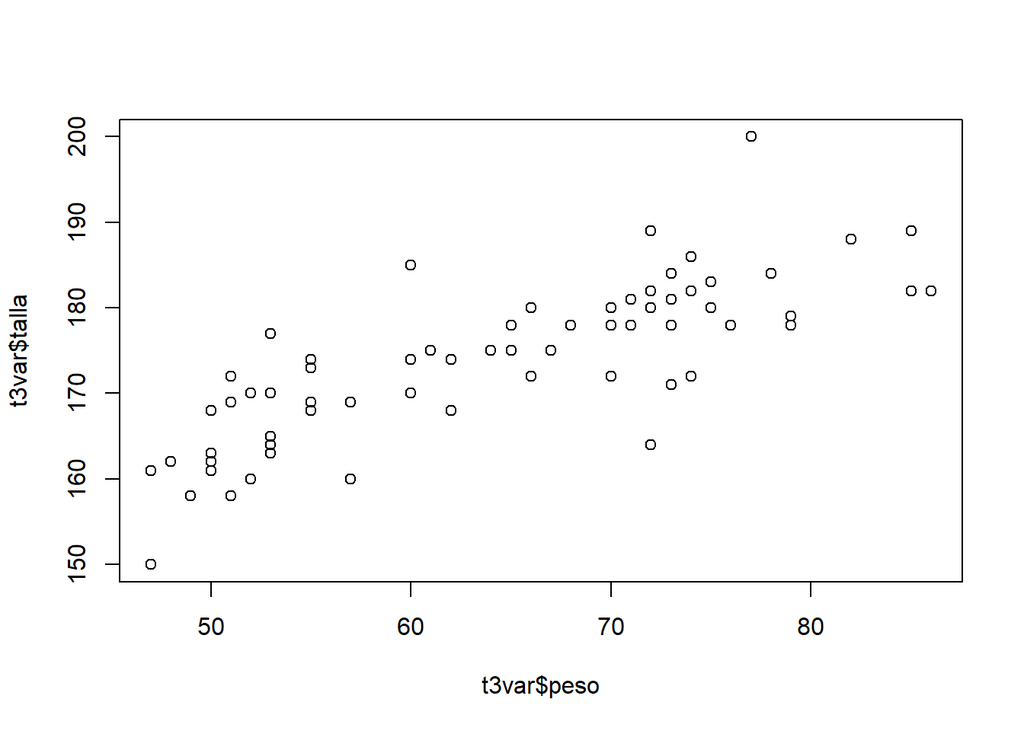

```r
plot(t3var$peso, t3var$talla)
```

If you want to extract some data you can use boolean operators like “==”

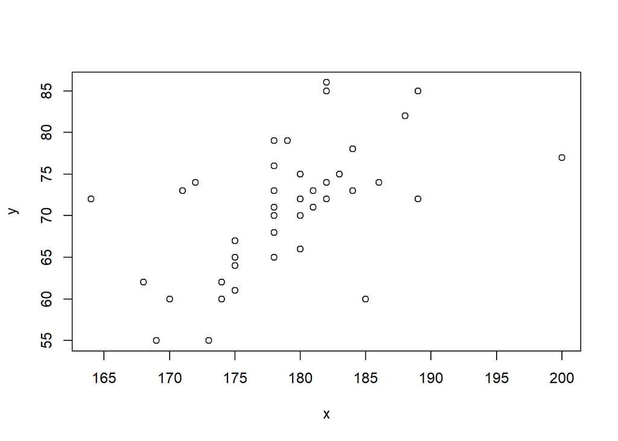

```r
x <- t3var$talla[t3var$sexo == "h"]
y <- t3var$peso[t3var$sexo == "h"]
plot(x, y)
```

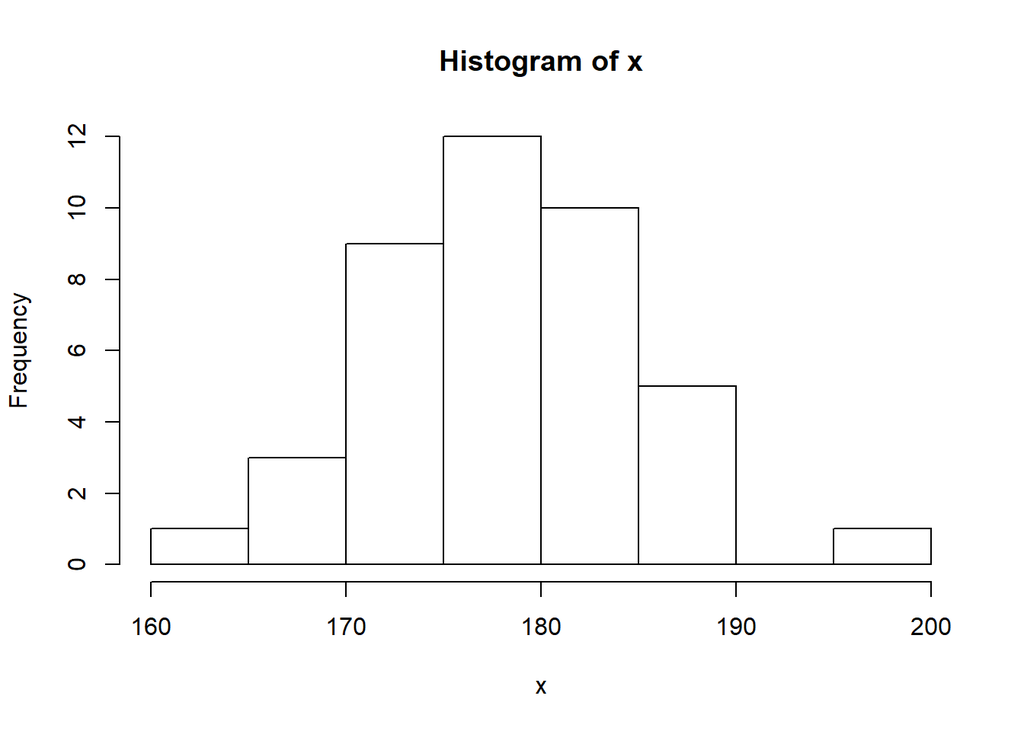

```r
hist(x)
```

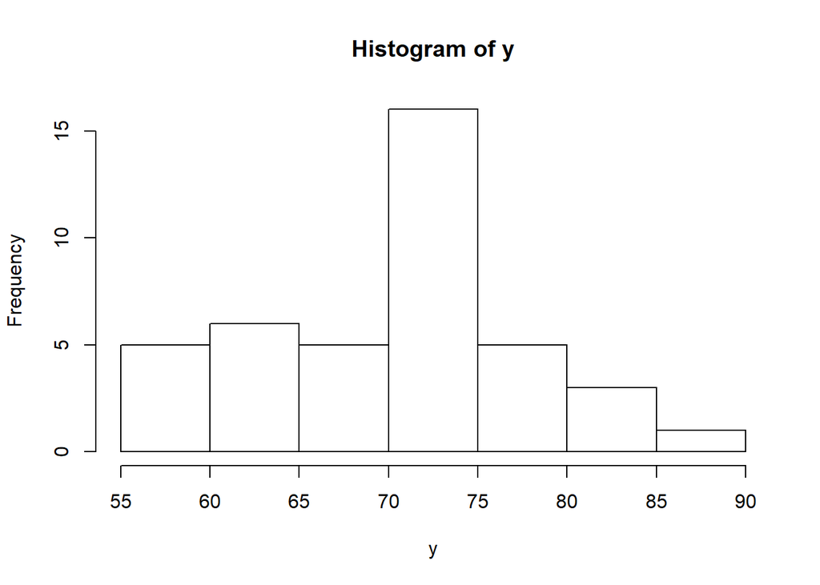

```r
hist(y)
```

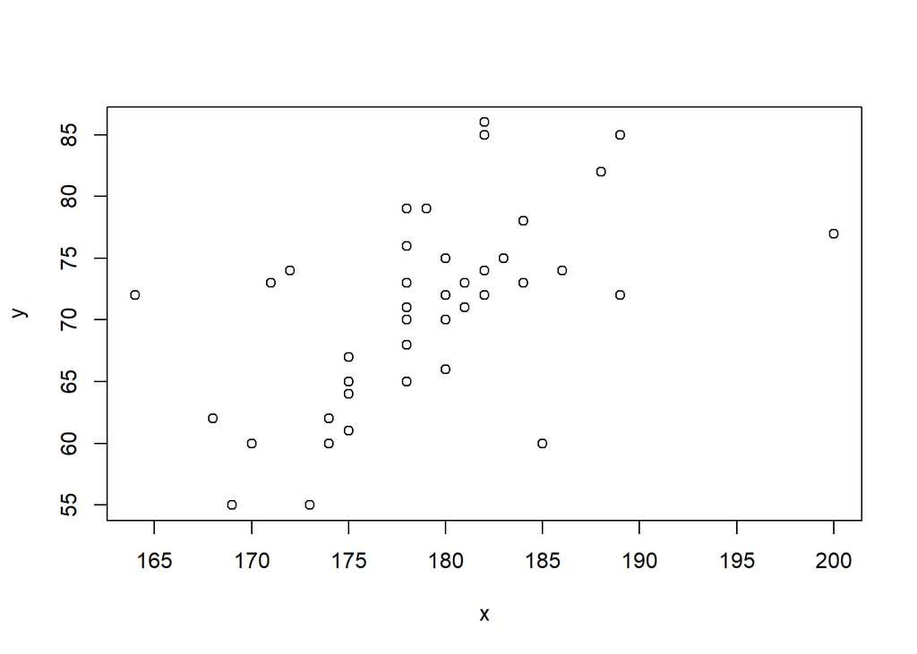

```r
x <- t3var$talla[t3var$sexo == "h"]
y <- t3var$peso[t3var$sexo == "h"]
plot(x, y)#plot of men's data
```

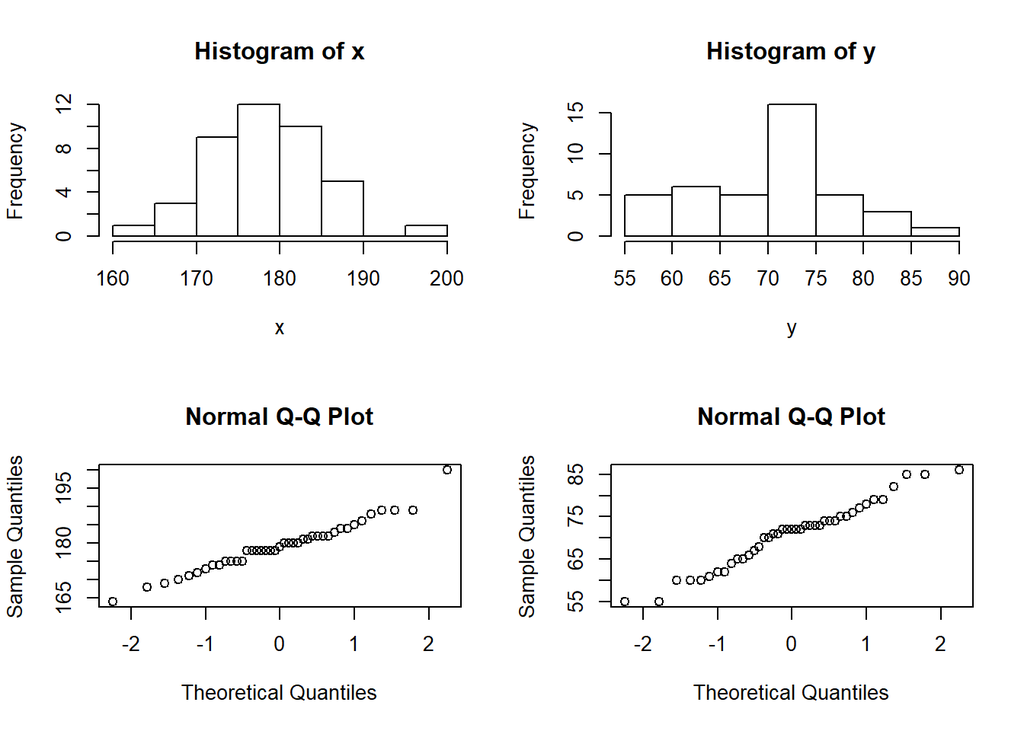

```r
par(mfrow = c(2, 2))#For plotting more than one plot on the same window
hist(x)
hist(y)
qqnorm(x)# a graphical way of testing adjustment to the normal distribution
qqnorm(y)
```

Suppose you want to save the men’s data. Create a matrix and save it as it is or as a data frame.

```r
M<-cbind(x,y)
dput(M, "Mensdata.csv")#use deget("Mensdata.csv") to load again
write.table(M, "MensdataDF.txt")#Use read.table to load again
```

R will recognize numerical data vectors and categorical data vectors as for example sexo of t2var

```r
class(t3var$sexo)
```

```
## [1] "factor"
```

```r
attach(t3var)#this command allows R to recognize the objects in the data frame
class(peso)
```

```
## [1] "integer"
```

If a variable is coded with numbers, there can be a confusion

```r
sitio<-c(1,1,1,1,1,1,1,1,1,0,0,0,0,0,0,0,0,0)
summary(sitio)
```

```
##    Min. 1st Qu.  Median    Mean 3rd Qu.    Max.
##     0.0     0.0     0.5     0.5     1.0     1.0
```

```r
summary(as.factor(sitio))
```

```
## 0 1
## 9 9
```

```r
sitio<-c(1,1,1,1,1,1,1,1,1,0,0,0,0,0,0,0,0,0,NA,NA,NA)
summary(as.factor(sitio))
```

```
##    0    1 NA's
##    9    9    3
```

```r
summary(as.factor(na.omit(sitio)))
```

```
## 0 1
## 9 9
```

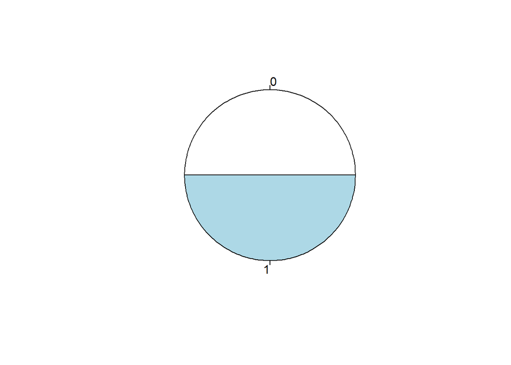

```r
pie(summary(as.factor(na.omit(sitio))))
```

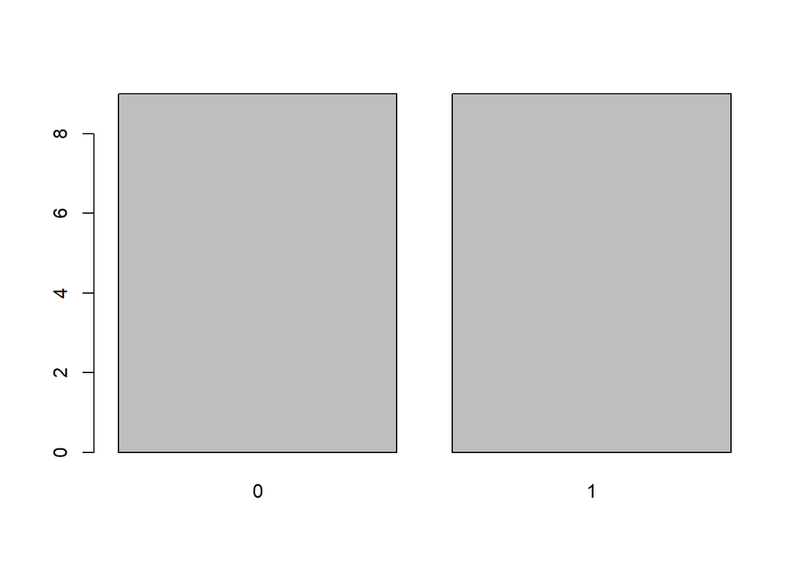

```r
barplot(summary(as.factor(na.omit(sitio))))
```

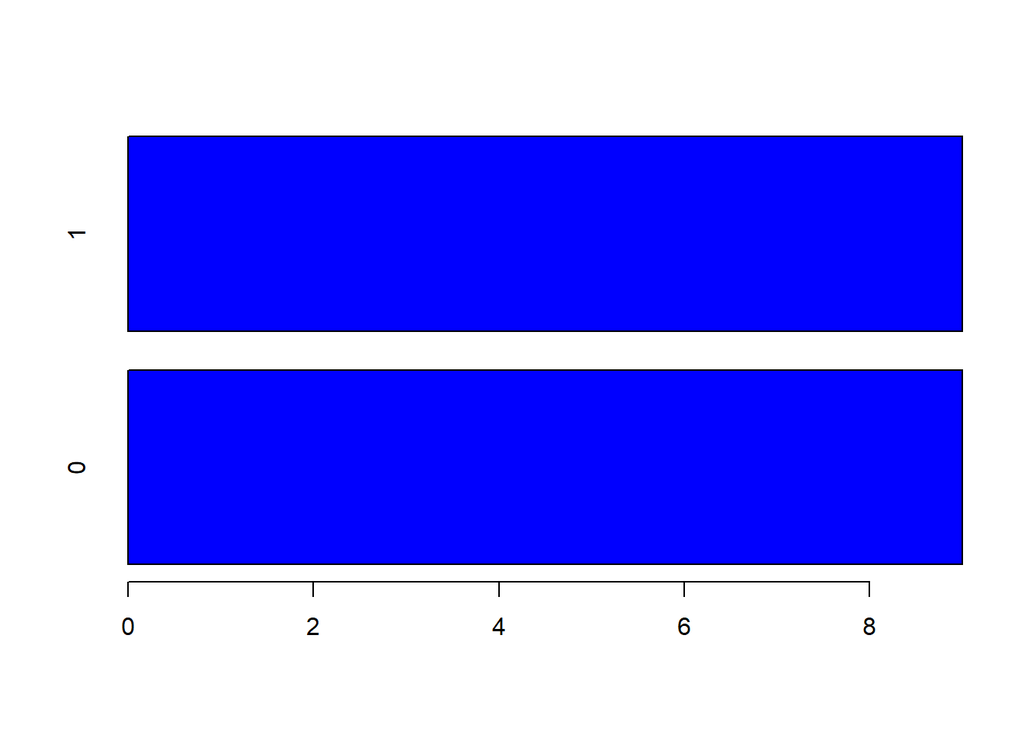

```r
barplot(summary(as.factor(na.omit(sitio))), horiz = TRUE, col="blue")
```

Outlier detection

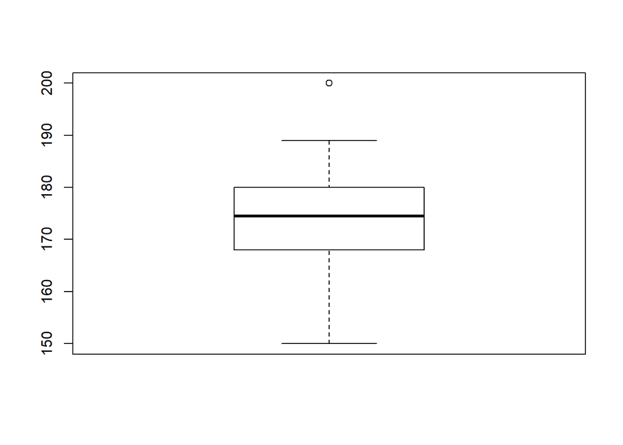

```r
boxplot(talla)
```

```r
boxplot.stats(talla)
```

```
## $stats
## [1] 150.0 168.0 174.5 180.0 189.0
##
## $n
## [1] 66
##
## $conf
## [1] 172.1662 176.8338
##
## $out
## [1] 200
```

```r
ind<-talla==200
t3var[ind,]
```

```
##    sexo peso talla
## 31    h   77   200
```

```r
ind<-talla>=189
length(ind)
```

```
## [1] 66
```

```r
t3var[ind,]
```

```
##    sexo peso talla
## 8     h   72   189
## 28    h   72   189
## 31    h   77   200
## 63    h   85   189
```

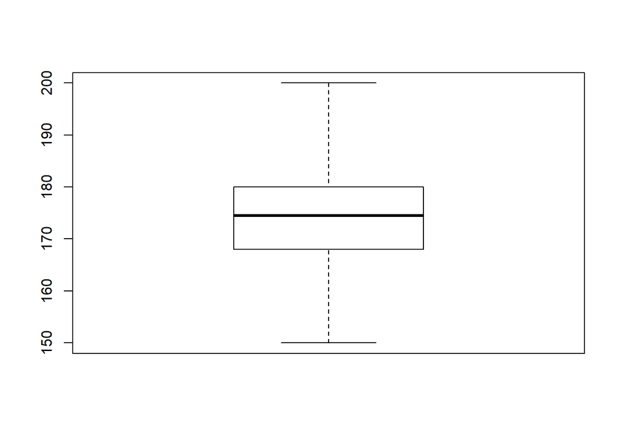

```r
#Changing the interquartile range to detect extreme outliers
boxplot(talla,range=3)
```

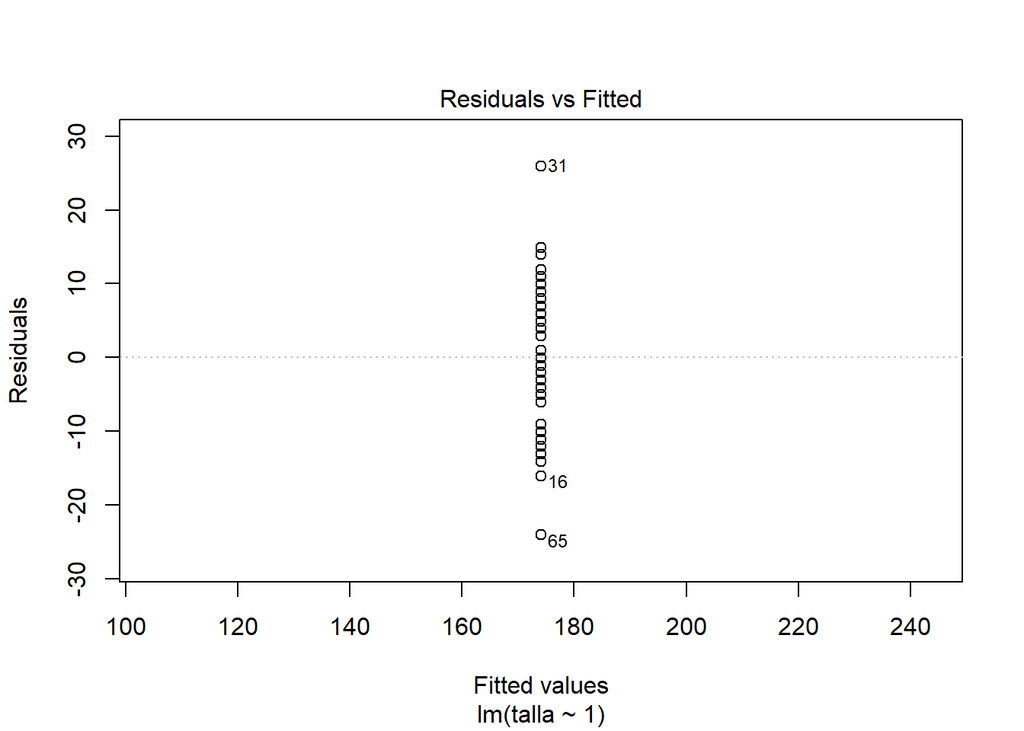

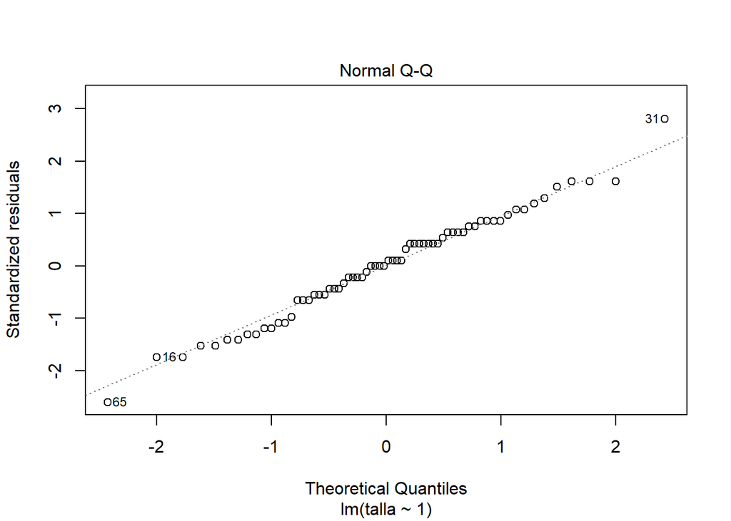

```
## hat values (leverages) are all = 0.01515152
##  and there are no factor predictors; no plot no. 5
```

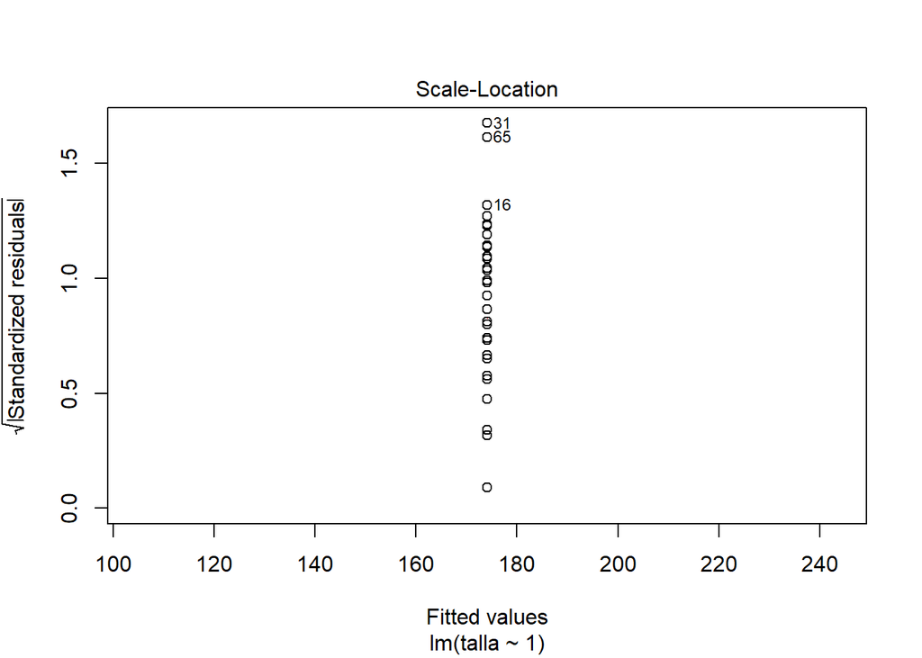

```r
plot(lm(talla ~ 1))
```

```r
#Multivariate outlier detection (here bivariate)
clmedians<-c(median(t3var$peso),median(t3var$talla))
mahalanobis(t3var[,2:3],mean(clmedians),cov(t3var[,2:3]))->mahat3var
#centers are the medians
length(mahat3var)
```

```
## [1] 66
```

```r
dim(t3var)
```

```
## [1] 66  3
```

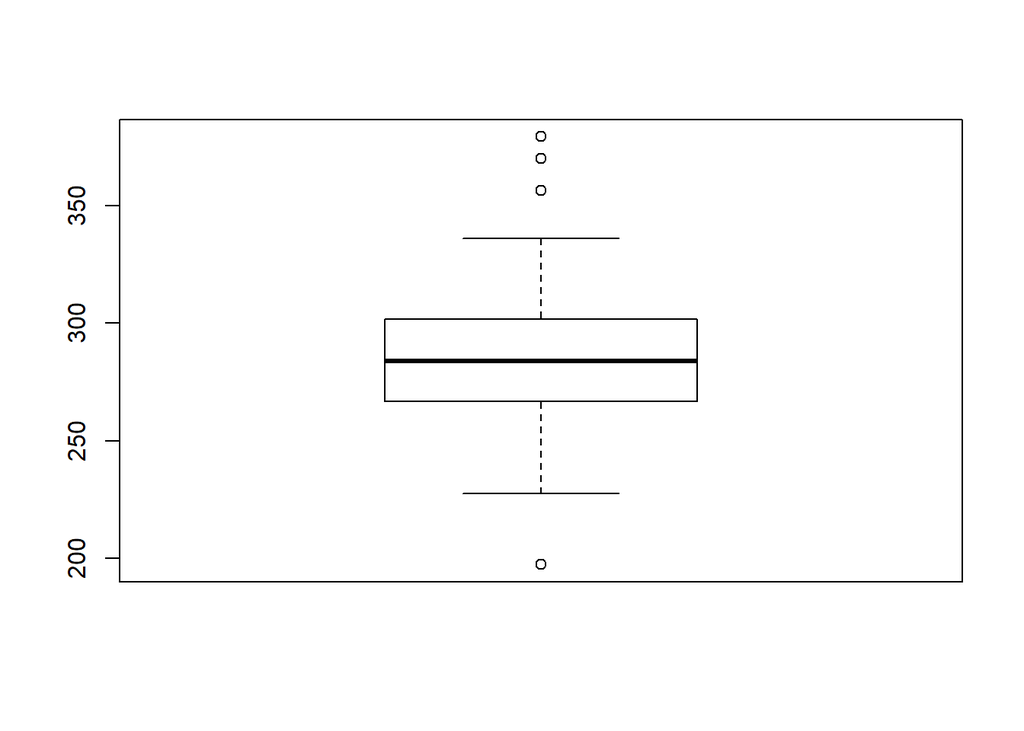

```r
boxplot(mahat3var)
```

```r
boxplot.stats(mahat3var)
```

```
## $stats
## [1] 227.5691 266.6785 284.0917 301.7039 336.1869
##
## $n
## [1] 66
##
## $conf
## [1] 277.2798 290.9036
##
## $out
## [1] 197.4943 370.1019 379.2839 356.4314
```

Now we are going to see how to handle a big data table, a gene expression table, for which an auxiliary annotation variable is available. The aim is to extract genes that are known to be resistance genes.

```r
tom2<-read.table("base-filtro3-6sept.txt",h=T) #tomato gene expression data
names(tom2) #in genes.filter the ID of the genes is found
```

```
##  [1] "grupo"        "genes.filter" "rep1"         "rep2"
##  [5] "rep3"         "rep4"         "rep5"         "rep6"
##  [9] "rep7"         "rep8"         "media"        "desv"
## [13] "cv"           "mediana"      "logrep1"      "logrep2"
## [17] "logrep3"      "logrep4"      "logrep5"      "logrep6"
## [21] "logrep7"      "logrep8"      "medialog"     "desvlog"
## [25] "cvlog"        "respdicotoma" "media3"       "media4"
## [29] "media5"       "media6"       "dicotoma1"    "dicotoma2"
## [33] "clasificador"
```

```r
attach(tom2)
genesR<-read.table("genes-resist.txt",h=T) #table indicating which genes are resistance genes (1) and which are not (0).
dim(genesR)
```

```
## [1] 13440     2
```

```r
names(genesR) #in genes.ori is the ID of all genes
```

```
## [1] "genes.ori"  "resistance"
```

```r
attach(genesR)
genes.resistance<-genes.ori[resistance==1] #extracts only names of resistance genes
length(genes.resistance)
```

```
## [1] 174
```

```r
indres<-which(genes.filter%in%genes.resistance) # finds these genes in the original gene expression table
genesres<-genes.filter[indres] #names of the resistance genes
length(genesres)
```

```
## [1] 177
```

```r
tomresist<-tom2[genes.filter[indres],c(15:22)] #extract data of the resistance genes. Only the variables of interest (log2 transformed data)
dim(tomresist)
```

```
## [1] 177   8
```

```r
write.table(tomresist,"tomresist.csv")#saves the new table
```

Some descriptive statistics

```r
x<-c(1,2,3,4,5,6,6,7,8,10)
mean(x)
```

```
## [1] 5.2
```

```r
var(x)
```

```
## [1] 7.733333
```

```r
sqrt(var(x))
```

```
## [1] 2.780887
```

```r
sd(x)
```

```
## [1] 2.780887
```

```r
median(1:4)
```

```
## [1] 2.5
```

```r
range(x)
```

```
## [1]  1 10
```

```r
quantile(x)
```

```
##    0%   25%   50%   75%  100%
##  1.00  3.25  5.50  6.75 10.00
```

Correlation coefficient

```r
cor(tomresist)#correlation between samples
```

```
##           logrep1   logrep2   logrep3   logrep4   logrep5   logrep6
## logrep1 1.0000000 0.9524665 0.9530492 0.9295526 0.9494218 0.9636092
## logrep2 0.9524665 1.0000000 0.9363628 0.9498265 0.9530310 0.9483838
## logrep3 0.9530492 0.9363628 1.0000000 0.9353657 0.9634930 0.9677839
## logrep4 0.9295526 0.9498265 0.9353657 1.0000000 0.9332091 0.9371357
## logrep5 0.9494218 0.9530310 0.9634930 0.9332091 1.0000000 0.9685218
## logrep6 0.9636092 0.9483838 0.9677839 0.9371357 0.9685218 1.0000000
## logrep7 0.9498064 0.9448503 0.9549197 0.9300203 0.9600570 0.9726355
## logrep8 0.9409057 0.9365451 0.9450531 0.9118654 0.9568753 0.9598458
##           logrep7   logrep8
## logrep1 0.9498064 0.9409057
## logrep2 0.9448503 0.9365451
## logrep3 0.9549197 0.9450531
## logrep4 0.9300203 0.9118654
## logrep5 0.9600570 0.9568753
## logrep6 0.9726355 0.9598458
## logrep7 1.0000000 0.9753193
## logrep8 0.9753193 1.0000000
```

```r
cor(tomresist,method="spearman")
```

```
##           logrep1   logrep2   logrep3   logrep4   logrep5   logrep6
## logrep1 1.0000000 0.9308176 0.9380094 0.9187954 0.9277976 0.9510235
## logrep2 0.9308176 1.0000000 0.9201815 0.9379730 0.9391958 0.9284932
## logrep3 0.9380094 0.9201815 1.0000000 0.9228596 0.9500923 0.9602728
## logrep4 0.9187954 0.9379730 0.9228596 1.0000000 0.9106163 0.9213939
## logrep5 0.9277976 0.9391958 0.9500923 0.9106163 1.0000000 0.9465780
## logrep6 0.9510235 0.9284932 0.9602728 0.9213939 0.9465780 1.0000000
## logrep7 0.9261352 0.9228389 0.9502395 0.9155633 0.9460317 0.9588345
## logrep8 0.9211652 0.9194408 0.9413739 0.8927414 0.9531424 0.9517492
##           logrep7   logrep8
## logrep1 0.9261352 0.9211652
## logrep2 0.9228389 0.9194408
## logrep3 0.9502395 0.9413739
## logrep4 0.9155633 0.8927414
## logrep5 0.9460317 0.9531424
## logrep6 0.9588345 0.9517492
## logrep7 1.0000000 0.9686513
## logrep8 0.9686513 1.0000000
```

```r
cor.test(tomresist[,1],tomresist[,2])#significance of correlation
```

```
##
##  Pearson's product-moment correlation
##
## data:  tomresist[, 1] and tomresist[, 2]
## t = 41.36, df = 175, p-value < 2.2e-16
## alternative hypothesis: true correlation is not equal to 0
## 95 percent confidence interval:
##  0.9365398 0.9644694
## sample estimates:
##       cor
## 0.9524665
```

A plot of the correlation in library corrplot

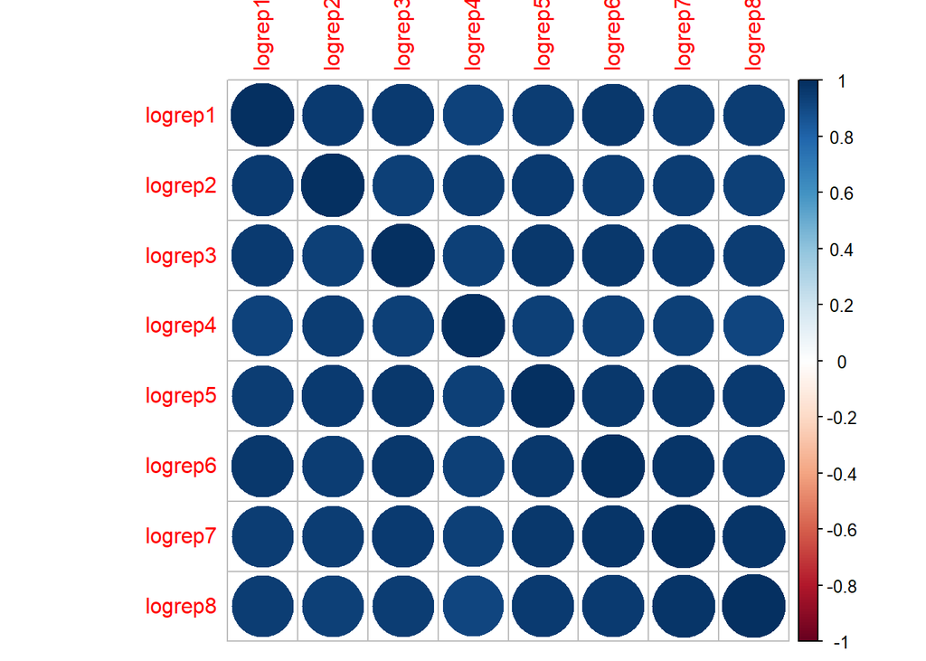

```r
#install.packages("corrplot")
library(corrplot)
corM<-cor(tomresist)
corrplot(corM,method = "circle")#all correlations are very high because they are replicates
```

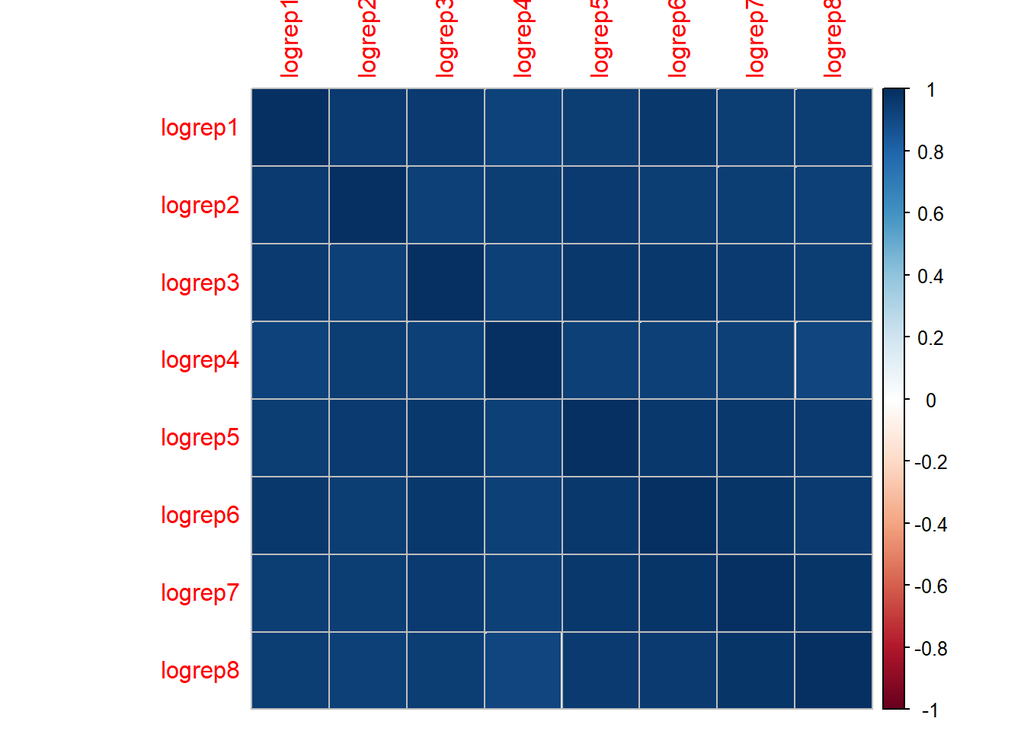

```r
corrplot(corM,method = "square")
```

Hypothesis testing

T-test

```r
#?t.test
t.test(1:10,mu=5)
```

```
##
##  One Sample t-test
##
## data:  1:10
## t = 0.52223, df = 9, p-value = 0.6141
## alternative hypothesis: true mean is not equal to 5
## 95 percent confidence interval:
##  3.334149 7.665851
## sample estimates:
## mean of x
##       5.5
```

```r
t.test(1:10,y<-c(7:20))
```

```
##
##  Welch Two Sample t-test
##
## data:  1:10 and y <- c(7:20)
## t = -5.4349, df = 21.982, p-value = 1.855e-05
## alternative hypothesis: true difference in means is not equal to 0
## 95 percent confidence interval:
##  -11.052802  -4.947198
## sample estimates:
## mean of x mean of y
##       5.5      13.5
```

```r
t.test(1:10,y<-c(7:20), var.equal=TRUE) # eliminates the Welch correction on degrees of freedom
```

```
##
##  Two Sample t-test
##
## data:  1:10 and y <- c(7:20)
## t = -5.1473, df = 22, p-value = 3.691e-05
## alternative hypothesis: true difference in means is not equal to 0
## 95 percent confidence interval:
##  -11.223245  -4.776755
## sample estimates:
## mean of x mean of y
##       5.5      13.5
```

```r
t.test(1:10,y<-c(7:20, 200))#T test does not work because normality assumption is not met
```

```
##
##  Welch Two Sample t-test
##
## data:  1:10 and y <- c(7:20, 200)
## t = -1.6329, df = 14.165, p-value = 0.1245
## alternative hypothesis: true difference in means is not equal to 0
## 95 percent confidence interval:
##  -47.242900   6.376233
## sample estimates:
## mean of x mean of y
##   5.50000  25.93333
```

```r
wilcox.test(1:10,y<-c(7:20, 200))
```

```
##
##  Wilcoxon rank sum test with continuity correction
##
## data:  1:10 and y <- c(7:20, 200)
## W = 8, p-value = 0.0002229
## alternative hypothesis: true location shift is not equal to 0
```

Chi-square test for independence

```r
sexe <- as.factor(rep(c("F", "M"), c(10, 10)))
examen <- as.factor(c("R", "R", "R", "R", "E", "E", "E","E", "E", "E", "R", "R", "R", "R", "R", "R", "E", "E", "E", "E"))
table(sexe,examen)
```

```
##     examen
## sexe E R
##    F 6 4
##    M 4 6
```

```r
chisq.test(sexe, examen)
```

```
##
##  Pearson's Chi-squared test with Yates' continuity correction
##
## data:  sexe and examen
## X-squared = 0.2, df = 1, p-value = 0.6547
```

```r
chisq.test(sexe, examen, correct = FALSE)#only if more than one degree of freedom
```

```
##
##  Pearson's Chi-squared test
##
## data:  sexe and examen
## X-squared = 0.8, df = 1, p-value = 0.3711
```

Fisher exact test when frequencies of the contingency table are less than 3

```r
TeaTasting <-
matrix(c(3, 1, 1, 3),
       nrow = 2,
       dimnames = list(Guess = c("Milk", "Tea"),
                       Truth = c("Milk", "Tea")))
fisher.test(TeaTasting, alternative = "greater")
```

```
##
##  Fisher's Exact Test for Count Data
##
## data:  TeaTasting
## p-value = 0.2429
## alternative hypothesis: true odds ratio is greater than 1
## 95 percent confidence interval:
##  0.3135693       Inf
## sample estimates:
## odds ratio
##   6.408309
```

Estimate power of a T test or fix a power and estimate sampling size. d is the effect size as described by Cohen.

```r
library(pwr)
pwr.t.test(d=0.2,n=60,sig.level=0.10,type="one.sample",alternative="two.sided")
```

```
##
##      One-sample t test power calculation
##
##               n = 60
##               d = 0.2
##       sig.level = 0.1
##           power = 0.4555818
##     alternative = two.sided
```

```r
pwr.t.test(d=0.2,power=0.90,sig.level=0.10,type="one.sample",alternative="two.sided")
```

```
##
##      One-sample t test power calculation
##
##               n = 215.4542
##               d = 0.2
##       sig.level = 0.1
##           power = 0.9
##     alternative = two.sided
```

```r
pwr.t.test(d=0.2,power=0.80,sig.level=0.010,type="one.sample",alternative="two.sided")
```

```
##
##      One-sample t test power calculation
##
##               n = 295.2973
##               d = 0.2
##       sig.level = 0.01
##           power = 0.8
##     alternative = two.sided
```

Power for analysis of variance

```r
power.anova.test(groups = 3, n = NULL, between.var = 43715, within.var = 102030, sig.level = 0.05,
power = 0.8)
```

```
##
##      Balanced one-way analysis of variance power calculation
##
##          groups = 3
##               n = 12.29934
##     between.var = 43715
##      within.var = 102030
##       sig.level = 0.05
##           power = 0.8
##
## NOTE: n is number in each group
```

Linear Regression

```r
MicroYprot<-read.table("MicroYProtprom.txt",h=T)
summary(MicroYprot)#Are there missing values?
```

```
##        ID        promMicro         promProt
##  OppB   :  2   Min.   :0.7468   Min.   :0.6295
##  260709 :  1   1st Qu.:0.8189   1st Qu.:0.7767
##  266157 :  1   Median :0.8429   Median :0.8386
##  266158 :  1   Mean   :0.8996   Mean   :1.0309
##  266176 :  1   3rd Qu.:0.9323   3rd Qu.:0.9397
##  266181 :  1   Max.   :1.7976   Max.   :4.9451
##  (Other):205                    NA's   :8
```

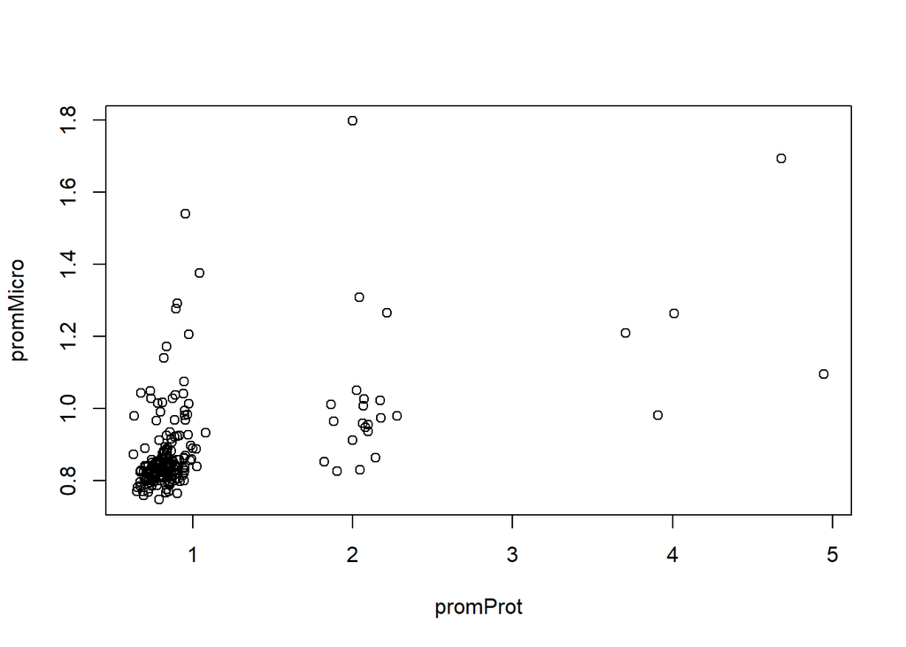

```r
attach(MicroYprot)
plot(promProt,promMicro)
```

```r
lmp<-lm(promProt~promMicro)#missing values are not used
summary(lmp)
```

```
##
## Call:
## lm(formula = promProt ~ promMicro)
##
## Residuals:
##     Min      1Q  Median      3Q     Max
## -1.5590 -0.1676 -0.0754  0.0049  3.4536
##
## Coefficients:
##             Estimate Std. Error t value Pr(>|t|)
## (Intercept)  -1.0195     0.2351  -4.337 2.28e-05 ***
## promMicro     2.2936     0.2595   8.840 4.75e-16 ***
## ---
## Signif. codes:  0 '***' 0.001 '**' 0.01 '*' 0.05 '.' 0.1 ' ' 1
##
## Residual standard error: 0.5441 on 202 degrees of freedom
##   (8 observations deleted due to missingness)
## Multiple R-squared:  0.2789, Adjusted R-squared:  0.2754
## F-statistic: 78.14 on 1 and 202 DF,  p-value: 4.749e-16
```

```r
#The quality of the model is very bad
protpred<-2.2936*promMicro[205]-1.0195#Predicting a missing value
protpred
```

```
## [1] 1.619354
```

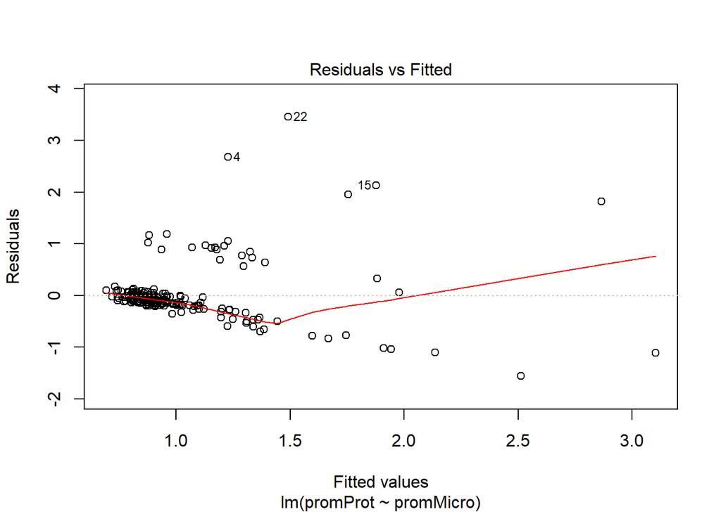

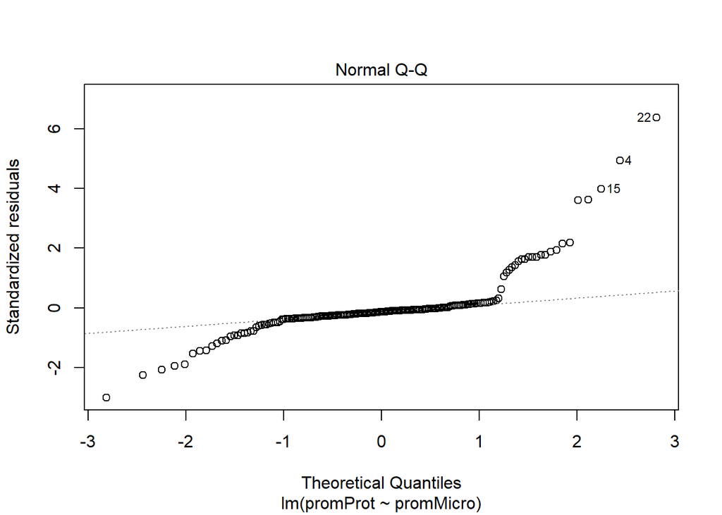

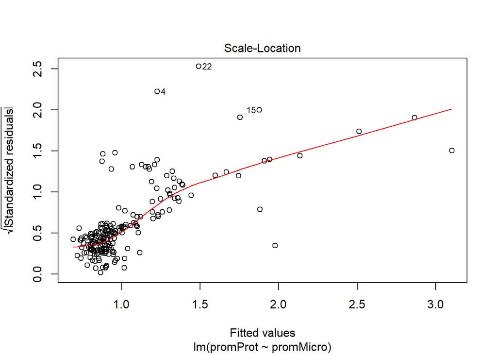

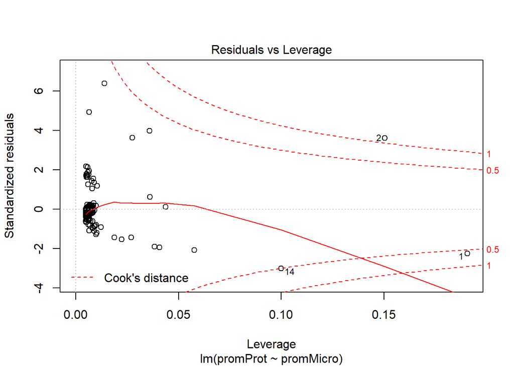

```r
#Testing for assumptions
#normal distribution of residuals
plot(lmp) #several plots are displayed
```

```r
shapiro.test(lmp$residuals)
```

```
##
##  Shapiro-Wilk normality test
##
## data:  lmp$residuals
## W = 0.69747, p-value < 2.2e-16
```

```r
#independence
#install.packages("lmtest")
library(lmtest)
dwtest(promProt[1:204]~promMicro[1:204])
```

```
##
##  Durbin-Watson test
##
## data:  promProt[1:204] ~ promMicro[1:204]
## DW = 2.2963, p-value = 0.9804
## alternative hypothesis: true autocorrelation is greater than 0
```

Multiple linear regression

```r
RLM<-read.table("RegrLinealMultiple.txt",h=T)
RLM
```

```
##       y X0    X1    X2   X3
## 1  25.5  1  1.74  5.30 10.8
## 2  31.2  1  6.32  5.42  9.4
## 3  25.9  1  6.22  8.41  7.2
## 4  38.4  1 10.52  4.63  8.5
## 5  18.4  1  1.19 11.60  9.4
## 6  26.7  1  1.22  5.85  9.9
## 7  26.4  1  4.10  6.62  8.0
## 8  25.9  1  6.32  8.72  9.1
## 9  32.0  1  4.08  4.42  8.7
## 10 25.2  1  4.15  7.60  9.2
## 11 39.7  1 10.15  4.38  9.4
## 12 35.7  1  1.72  3.12  7.6
## 13 26.5  1  1.70  5.30  8.2
```

```r
X<-RLM[1:13,3:5]
X<-as.matrix(X)
y<-RLM[1:13,1]
t(X)
```

```
##        1    2    3     4     5    6    7    8    9   10    11   12  13
## X1  1.74 6.32 6.22 10.52  1.19 1.22 4.10 6.32 4.08 4.15 10.15 1.72 1.7
## X2  5.30 5.42 8.41  4.63 11.60 5.85 6.62 8.72 4.42 7.60  4.38 3.12 5.3
## X3 10.80 9.40 7.20  8.50  9.40 9.90 8.00 9.10 8.70 9.20  9.40 7.60 8.2
```

```r
lmR<-lm(y~X)
lmR
```

```
##
## Call:
## lm(formula = y ~ X)
##
## Coefficients:
## (Intercept)          XX1          XX2          XX3
##     39.7919       0.9754      -1.8628      -0.4002
```

```r
summary(lmR)#this is a good model
```

```
##
## Call:
## lm(formula = y ~ X)
##
## Residuals:
##     Min      1Q  Median      3Q     Max
## -1.8575 -1.4111 -0.1708  0.5779  3.0842
##
## Coefficients:
##             Estimate Std. Error t value Pr(>|t|)
## (Intercept)  39.7919     5.6203   7.080 5.79e-05 ***
## XX1           0.9754     0.1825   5.346 0.000465 ***
## XX2          -1.8628     0.2523  -7.384 4.17e-05 ***
## XX3          -0.4002     0.5867  -0.682 0.512280
## ---
## Signif. codes:  0 '***' 0.001 '**' 0.01 '*' 0.05 '.' 0.1 ' ' 1
##
## Residual standard error: 1.972 on 9 degrees of freedom
## Multiple R-squared:  0.9201, Adjusted R-squared:  0.8935
## F-statistic: 34.54 on 3 and 9 DF,  p-value: 2.882e-05
```

Analysis of variance

```r
dosis<-read.table("dosis.txt",h=T)
attach(dosis)

bartlett.test(Vigilancia~Dosis)
```

```
##
##  Bartlett test of homogeneity of variances
##
## data:  Vigilancia by Dosis
## Bartlett's K-squared = 4.4546, df = 2, p-value = 0.1078
```

```r
by(Vigilancia, Dosis, shapiro.test)
```

```
## Dosis: a
##
##  Shapiro-Wilk normality test
##
## data:  dd[x, ]
## W = 0.96129, p-value = 0.8296
##
## --------------------------------------------------------
## Dosis: b
##
##  Shapiro-Wilk normality test
##
## data:  dd[x, ]
## W = 0.99106, p-value = 0.9965
##
## --------------------------------------------------------
## Dosis: c
##
##  Shapiro-Wilk normality test
##
## data:  dd[x, ]
## W = 0.97137, p-value = 0.85
```

```r
ks.test(Vigilancia[1:6], "pnorm",mean(Vigilancia[1:6]),sd(Vigilancia[1:6]))#Kolmogorov-Smirnov test for normality
```

```
##
##  One-sample Kolmogorov-Smirnov test
##
## data:  Vigilancia[1:6]
## D = 0.14767, p-value = 0.9967
## alternative hypothesis: two-sided
```

```r
#1 Factor ANOVA
aov.dosis<- aov(Vigilancia~Dosis,data=dosis)
summary(aov.dosis)
```

```
##             Df Sum Sq Mean Sq F value  Pr(>F)
## Dosis        2  426.2  213.12   8.789 0.00298 **
## Residuals   15  363.8   24.25
## ---
## Signif. codes:  0 '***' 0.001 '**' 0.01 '*' 0.05 '.' 0.1 ' ' 1
```

```r
#Multiple testing
pairwise.t.test(Vigilancia,Dosis)
```

```
##
##  Pairwise comparisons using t tests with pooled SD
##
## data:  Vigilancia and Dosis
##
##   a      b
## b 0.1309 -
## c 0.0025 0.0185
##
## P value adjustment method: holm
```

```r
pairwise.t.test(Vigilancia,Dosis,p.adjust="bonf")
```

```
##
##  Pairwise comparisons using t tests with pooled SD
##
## data:  Vigilancia and Dosis
##
##   a      b
## b 0.3926 -
## c 0.0025 0.0278
##
## P value adjustment method: bonferroni
```

```r
#2 Factor ANOVA
aov.dosis<- aov(Vigilancia~Genero+Dosis,data=dosis)
summary(aov.dosis)
```

```
##             Df Sum Sq Mean Sq F value  Pr(>F)
## Genero       1   22.2   22.22   0.911 0.35606
## Dosis        2  426.2  213.12   8.736 0.00345 **
## Residuals   14  341.5   24.39
## ---
## Signif. codes:  0 '***' 0.001 '**' 0.01 '*' 0.05 '.' 0.1 ' ' 1
```

```r
aov.dosis<- aov(Vigilancia~Genero+Dosis+Genero*Dosis,data=dosis)
summary(aov.dosis)
```

```
##              Df Sum Sq Mean Sq F value  Pr(>F)
## Genero        1   22.2   22.22   0.806 0.38695
## Dosis         2  426.2  213.12   7.730 0.00696 **
## Genero:Dosis  2   10.7    5.35   0.194 0.82623
## Residuals    12  330.8   27.57
## ---
## Signif. codes:  0 '***' 0.001 '**' 0.01 '*' 0.05 '.' 0.1 ' ' 1
```

```r
#Another way of multiple testing
TukeyHSD(aov.dosis, "Dosis", ordered = TRUE)
```

```
##   Tukey multiple comparisons of means
##     95% family-wise confidence level
##     factor levels have been ordered
##
## Fit: aov(formula = Vigilancia ~ Genero + Dosis + Genero * Dosis, data = dosis)
##
## $Dosis
##      diff        lwr      upr     p adj
## b-c  9.00  0.4218572 17.57814 0.0396587
## a-c 13.25  4.2078436 22.29216 0.0054400
## a-b  4.25 -3.3152108 11.81521 0.3258550
```

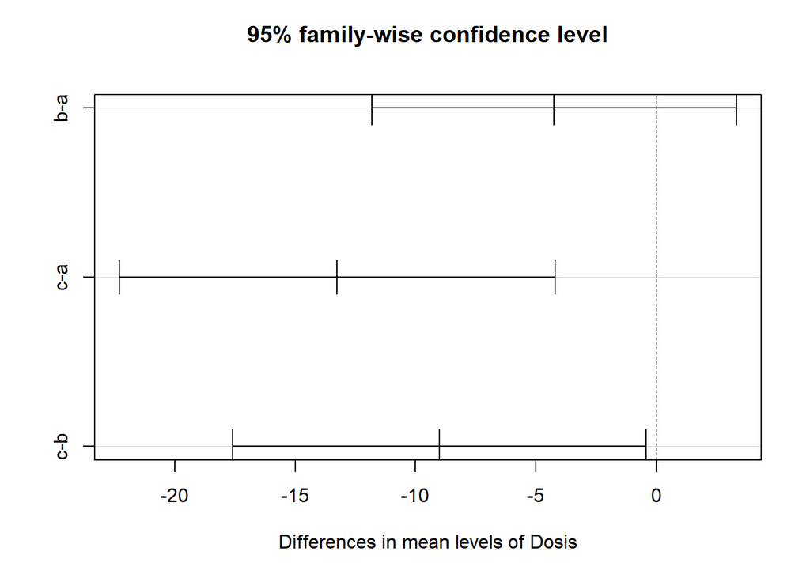

```r
plot(TukeyHSD(aov.dosis, "Dosis"))
```

If the normality assumption is not met, a 1 Factor ANOVA can be replaced by the non-parametric Kruskal-Wallis test

```r
kruskal.test(Vigilancia~Dosis,data=dosis)
```

```
##
##  Kruskal-Wallis rank sum test
##
## data:  Vigilancia by Dosis
## Kruskal-Wallis chi-squared = 9.4272, df = 2, p-value = 0.008972
```

For the experimental design, in order to assure randomization, the following library can be used

```r
#install.packages("agricolae")
library(agricolae)
trt<-c(3,2) # factorial 3x2
outdesign <-design.ab(trt, r=3, serie=2)

# factorial 2 x 2 x 2 with 5 replications in completely randomized design.
trt<-c(2,2,2)
outdesign<-design.ab(trt, r=5, serie=2,design="crd") #complete randomized design

# factorial 3 x 3 in latin square design.
trt <-c(3,3)
outdesign<-design.ab(trt, serie=2, design="lsd") #latin square design

#incomplete blocks
# 4 treatments and k=3 size block
trt<-c("A","B","C","D")
k<-3
outdesign<-design.bib(trt,k,serie=2,seed =41) # seed = 41 print(outdesign$parameters)
```

```
##
## Parameters BIB
## ==============
## Lambda     : 2
## treatmeans : 4
## Block size : 3
## Blocks     : 4
## Replication: 3
##
## Efficiency factor 0.8888889
##
## <<< Book >>>
```

```r
#Marsaglia's famous Super-Duper method to generate random numbers as default
book<-outdesign$book
plots <-as.numeric(book[,1])
matrix(plots,byrow=TRUE,ncol=k)
```

```
##      [,1] [,2] [,3]
## [1,]  101  102  103
## [2,]  201  202  203
## [3,]  301  302  303
## [4,]  401  402  403
```

```r
print(outdesign$sketch)
```

```
##      [,1] [,2] [,3]
## [1,] "D"  "B"  "A"
## [2,] "B"  "A"  "C"
## [3,] "B"  "D"  "C"
## [4,] "A"  "C"  "D"
```

Some useful functions

```r
#apply
    x <- cbind(x1 = 3, x2 = c(4:1, 2:5))
    dimnames(x)[[1]] <- letters[1:8]
    #?apply
    col.sums <- apply(x, 2, sum)
    col.sums <- apply(x, 1, sum)
    lapply(x, mean)
```

```
## [[1]]
## [1] 3
##
## [[2]]
## [1] 3
##
## [[3]]
## [1] 3
##
## [[4]]
## [1] 3
##
## [[5]]
## [1] 3
##
## [[6]]
## [1] 3
##
## [[7]]
## [1] 3
##
## [[8]]
## [1] 3
##
## [[9]]
## [1] 4
##
## [[10]]
## [1] 3
##
## [[11]]
## [1] 2
##
## [[12]]
## [1] 1
##
## [[13]]
## [1] 2
##
## [[14]]
## [1] 3
##
## [[15]]
## [1] 4
##
## [[16]]
## [1] 5
```

```r
 sapply(x, mean)
```

```
##  [1] 3 3 3 3 3 3 3 3 4 3 2 1 2 3 4 5
```

Constructing loops

```r
x12<- c(5,4,3,2)
    for(i in 1:3){x12[i] <- x12[i] + 1}
    x12
```

```
## [1] 6 5 4 2
```

```r
    #[1] 6 5 4 2
    x12 <- x12 + 1
    for(i in 1:length(x12)){x12[i] <- x12[i] + 1}
    for(i in 1:length(x12)){if(x12[i] < 4){x12[i] <- x12[i] + 1}}

    if ( x > 3) { resultado <- "x es mayor de 3"}   # Efectúa la comparación.
#A simple function
    x<-5
    f <- function(x) {
     x^2 + x + 1
    }
    f(x)
```

```
## [1] 31
```